# Human-Robot Interaction

## Tutorial 2: Robot learning part 2: Mixed Density Networks

**Authors: Pablo Lanillos and Zied Tayeb**

**Date**16/09/2020

**Sources**:

1. Christopher M. Bishop. Mixed Density Networks (1994). https://publications.aston.ac.uk/id/eprint/373/1/NCRG_94_004.pdf
2. Lanillos, P., Pages, J. & Cheng, G. (2020). Robot self/other distinction: active inference meets neural networks learning in a mirror. European Conference on Artificial Intelligence (ECAI). https://arxiv.org/abs/2004.05473
3. https://blog.otoro.net/2015/11/24/mixture-density-networks-with-tensorflow/

## 1.1 Review of Gaussian function

## Normal Distribution

Let's plot the PDF (probability density function) of a normal distribution. The function is as follows:

$$\mathcal{N}(x \mid \mu, \sigma^2) = \frac{1}{\sqrt{2\pi\sigma^2} } e^{ -\frac{(x-\mu)^2}{2\sigma^2} }$$

Where $\mu$ and $\sigma$ are the mean and standard deviation.

$\mathcal{N}(x \mid \mu, \sigma^2)$ is the 'relative' likelihood of drawing $x$ from the model parametrised by $\mu$ and $\sigma$.

# Probability density function

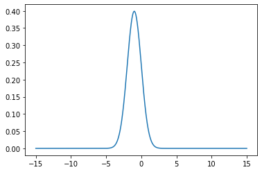

```python
from matplotlib import pyplot as mp
%matplotlib inline
import numpy as np

from matplotlib import pyplot as mp
import numpy as np

def gaussian(x, mu, sig):
    return  1/np.sqrt(2 * np.pi * sig**2) * np.exp(- (x - mu)**2 / (2 * sig**2) )

x_values = np.linspace(-15,15,1000)
for mu, sig in [(-1, 1)]:
    mp.plot(x_values, gaussian(x_values, mu, sig))

mp.show()
```

# Probability vs Likelihood: Difference

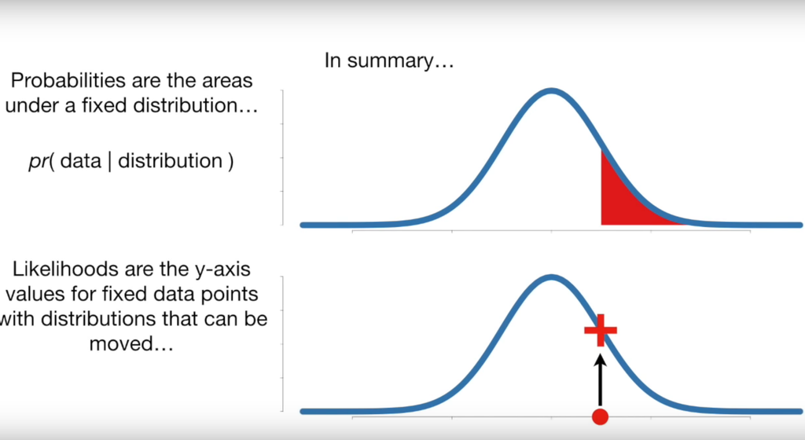

```python
from IPython.display import Image
Image("likelihood.png")
```

# Bottleneck: Modelling multiple distributions

```
Plotting with normal distribution with mu= -0.10499489503241875 and sd= 5.596157340563664
```

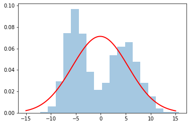

```python
import seaborn as sns
import matplotlib.pyplot as plt
# Let's try modelling two different distributions
s1 = np.random.normal(-5, 2.0, 1000)
s2 = np.random.normal(5, 3.0, 1000)
all_s = np.concatenate([s1, s2])
s_mean = np.mean(all_s) # calculate mean of the whole sample
s_sd = np.std(all_s) # calculate standard deviation of the whole sample.

print("Plotting with normal distribution with mu=", s_mean, "and sd=", s_sd)
sns.distplot(all_s, hist=True, kde=False, norm_hist=True)
sns.lineplot(x_values, gaussian(x_values, s_mean, s_sd), linewidth=2, color='r')
plt.savefig("complex_distribution_hist_and_normal.png", dpi=150, bbox_inches='tight')
```

## Solution! Mixture Distribution

A mixture distribution lets us mix multiple different distributions together. In our case, we're just considering mixtures of normal models, but you can mix other models as well. The idea is to weight each distribution, so some might be more or less important, and then add them together.

- Suppose that you have $K$ mixture components (number of distributions).
- Then you need $K$ distribution parameters ($\mu$ and $\sigma$), one for each component. Let's call these $\mu_i$ and $\sigma_i$ where $i \in [1, \ldots, K]$.
- Finally we need some weights $\pi_i$, $i \in [1, \ldots, K]$, such that $\sum_{i=1}^K \pi_i = 1$

Now the PDF of this mixture model will be:

$$p(x) = \sum_{i=1}^K \pi_i\mathcal{N}(x \mid \mu, \sigma^2)$$

That is, the likelihood of $x$ occuring in the distribution is the sum of the weighted likelihoods for $x$ from each Guassian model.

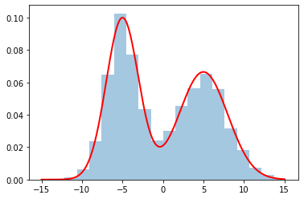

```python
def mixture_of_normals_pdf(x, K, pis, mus, sigmas):
    """PDF for a mixture model of K normal distributions"""
    output = 0
    for i in range(K):
        output += pis[i] *gaussian(x, mus[i], sigmas[i])
    return output


sns.distplot(all_s, hist=True, kde=False, norm_hist=True)
sns.lineplot(x_values, mixture_of_normals_pdf(x_values, 2, [0.5,0.5], [-5,5], [2,3]), linewidth=2, color='r')
plt.savefig("complex_distribution_hist_and_mixture.png", dpi=150, bbox_inches='tight')
```

# 1. What is a mixture density network?

Mixture density network: What, Why and how

instead of predicting one single value (neural network for regression: One output neuron for regression), we model all uncertainty behind that point. That is basically a mixture density network. Rather than predicting y, you predict a bunch of pi, mean and std . You sample from that to get your real value

We try to do continuous variable prediction under uncertainty!

Example: If I ask question, I don’t want to hear one single answer but rather a range of answers to assess the probability of each answer! Therefore, we can improve our understanding of the prediction and may even make a better-informed decision! The probability density of the target data is then represented as a linear combination of kernel functions in the form!

Combining a feedforward network and a mixture model is what we call mixture density network |

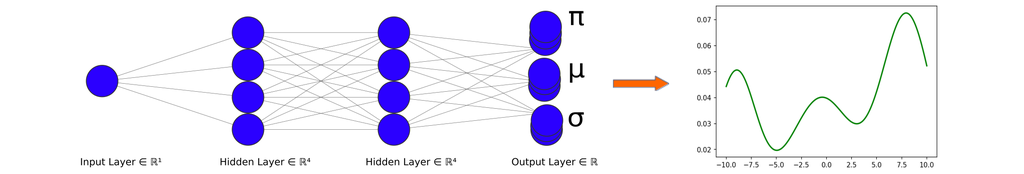

```python
from IPython.display import Image
Image("mdn.png")
```

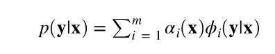

```python
from IPython.display import Image
Image("gaussian_kernel.png")
```

# Loss function

# Probability of target value given an input feature (update the distribution accordingly)

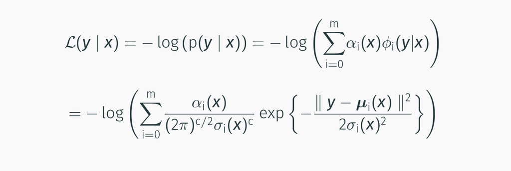

```python
from IPython.display import Image
Image("loss.png")
```

Where the coefficients sums to 1 $\sum_i \alpha_i = 1$ and the kernel $\phi$ is the Normal distribution.

# Example problem: Single input and multiple outputs

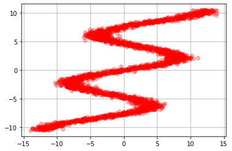

```python
## Generate the data:
NSAMPLE = 3000
# check the tutorial document on how to generate the data and write the function generate_data(n_samples)
# y,x =
# plot. It should output something simliar like:
```

### Did you try out the Feed-forward for regression (MSE) ?

Write your own FFN to test with the data and plot the **loss function**.

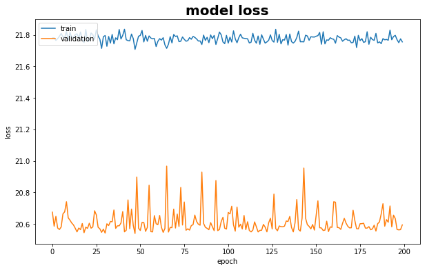

```python
# Example of loss plot
from IPython.display import Image
Image("ffn_loss_mdndata.png")
```

# Build the MDN Model

```python
#imports
from mpl_toolkits.mplot3d import Axes3D
import matplotlib.pyplot as plt # creating visualizations
import numpy as np # basic math and random numbers
import torch # package for building functions with learnable parameters
import torch.nn as nn # prebuilt functions specific to neural networks
from torch.autograd import Variable # storing data while learning
from torch.distributions import constraints, multivariate_normal
from torch.distributions.distribution import Distribution
```

```python
# Program the MDN Network
# NN output is (N_OUTPUT+2)*N_MIXES

class MDN(nn.Module):
    def __init__(self, n_input, n_hidden, n_output, n_gaussians):
        super(MDN, self).__init__()
        #Code your MDN

    def forward(self, x):
        #Program the forward pass
        return pi, sigma, mu
```

```python
# Program the loss function

def gaussian_distribution(y, mu, sigma):
    sigma_1 =  torch.reciprocal(sigma) # sigma^{-1}
    # program the gaussian distribution using torch functions

    return p

def mdn_loss(pi,sigma,mu,y):
  N, K = pi.shape #K = ngaussians
  _, KT = mu.shape #KT = ngaussians*noutput
  _,T = y.shape # T = noutputs
  losses = Variable(torch.zeros(N))  # p(y|x)
  # Compute the loss function

  return loss
```

```python
# instantiate the network, train it and plot the training loss
x = x.reshape(x.shape[0],1) # To transform into a matrix. This is an special case for 1 dimension
y = y.reshape(y.shape[0],1) # To transform into a matrix. This is an special case for 1 dimension

n_input = 1 # x.shape[1]
n_output = 1 # y.shape[1]
N_HIDDEN = 20
N_GAUSSIANS = 5
print(x.shape, y.shape)
```

```
(3000, 1) (3000, 1)
```

```python
# Instantiate the network
model = MDN(n_input=n_input, n_hidden=N_HIDDEN, n_output=n_output, n_gaussians=N_GAUSSIANS)
print(model)
optimizer = torch.optim.Adam(model.parameters()) # Select optimizer

# Write the training function train_mdn(n_epoch=10000)
def train_mdn(n_epoch=10000):
    for epoch in range(n_epoch):
        # program your training

        if epoch % 500 == 0:
            print(epoch, loss.item())
```

[output not shown]

```python
# data to train
x_tensor = torch.from_numpy(np.float32(x).reshape(x.shape[0], n_input))
y_tensor = torch.from_numpy(np.float32(y).reshape(y.shape[0], n_output))

x_variable = Variable(x_tensor)
y_variable = Variable(y_tensor, requires_grad=False)

train_mdn()
```

[output not shown]